# Question1

You will analyze data from a website with 8 pages (plus a 9th state, indicating that the user has left the website). Formulate a Markov chain for this website where each state {Si | i = 1, · · · , 9} corresponds to a page. Each visitor starts at the home page (Page 1), then browses from page-to-page until he/she leaves the website. So, a sample path may be S1 → S3 → S5 → S9, corresponding to a visitor starting on the home page, moving to Page 3, then Page 5, then leaving the website.

Attached is the dataset webtraffic.txt, which records the paths of 1000 visitors (rows). The data has 81 columns labeled t11, t12, · · · , t19, t21, t22, · · · , t99, where tij represents a transition from State i to State j, for i, j ∈ {1, · · · , 9}. Each visitor has a 1 in column tij if the visitor clicked from Page i to Page j, and 0 elsewhere. For example, the aforementioned sample path would have 1’s in columns t13, t35, and t59 and 0’s elsewhere.

## 1a)

Construct a 9 by 9 matrix Traffic that counts total traffic from State i to State j, for i, j ∈ {1, · · · , 9}. Note that Traffic has 0’s in row 9 and column 1. Set Traffic[9,1]=1000. (This is equivalent to making each user return to the home page after they leave the website.) Display Traffic. Hint: colSums() adds all rows for each column.

```r
df <- read.table('webtraffic.txt', header=TRUE)
head(df)
```

A data.frame: 6 × 81

|  | t11 <int> | t12 <int> | t13 <int> | t14 <int> | t15 <int> | t16 <int> | t17 <int> | t18 <int> | t19 <int> | t21 <int> | ⋯ | t89 <int> | t91 <int> | t92 <int> | t93 <int> | t94 <int> | t95 <int> | t96 <int> | t97 <int> | t98 <int> | t99 <int> |
| --- | --- | --- | --- | --- | --- | --- | --- | --- | --- | --- | --- | --- | --- | --- | --- | --- | --- | --- | --- | --- | --- |
| 1 | 0 | 1 | 0 | 0 | 0 | 0 | 0 | 0 | 0 | 0 | ⋯ | 1 | 0 | 0 | 0 | 0 | 0 | 0 | 0 | 0 | 0 |
| 2 | 0 | 0 | 1 | 0 | 0 | 0 | 0 | 0 | 0 | 0 | ⋯ | 1 | 0 | 0 | 0 | 0 | 0 | 0 | 0 | 0 | 0 |
| 3 | 0 | 0 | 1 | 0 | 0 | 0 | 0 | 0 | 0 | 0 | ⋯ | 0 | 0 | 0 | 0 | 0 | 0 | 0 | 0 | 0 | 0 |
| 4 | 0 | 0 | 1 | 0 | 0 | 0 | 0 | 0 | 0 | 0 | ⋯ | 0 | 0 | 0 | 0 | 0 | 0 | 0 | 0 | 0 | 0 |
| 5 | 0 | 1 | 0 | 0 | 0 | 0 | 0 | 0 | 0 | 0 | ⋯ | 1 | 0 | 0 | 0 | 0 | 0 | 0 | 0 | 0 | 0 |
| 6 | 0 | 0 | 1 | 0 | 0 | 0 | 0 | 0 | 0 | 0 | ⋯ | 1 | 0 | 0 | 0 | 0 | 0 | 0 | 0 | 0 | 0 |

```r
# 2. Initialize a 9x9 matrix with zeros
Traffic <- matrix(0, nrow=9, ncol=9)

# Populate the Traffic matrix
for (i in 1:9) {
  for (j in 1:9) {
    column_name <- paste0("t", i, j)
    #print(column_name)
    Traffic[i, j] <- sum(df[[column_name]])
  }
}

# 3. Set Traffic[9,1] to 1000
Traffic[9,1] <- 1000

# Display the Traffic matrix
print(Traffic)
```

```
      [,1] [,2] [,3] [,4] [,5] [,6] [,7] [,8] [,9]
 [1,]    0  447  553    0    0    0    0    0    0
 [2,]    0   23  230  321    0    0    0    0   63
 [3,]    0  167   43  520    0    0    0    0   96
 [4,]    0    0    0   44  158  312  247    0  124
 [5,]    0    0    0    0   22   52   90  127  218
 [6,]    0    0    0    0   67   21    0  294   97
 [7,]    0    0    0    0    0   94    7  185   58
 [8,]    0    0    0    0  262    0    0   30  344
 [9,] 1000    0    0    0    0    0    0    0    0
```

## 1b)

Draw a directed graph where each node represents a state, and each arrow from State i to State j has positive (non-zero) traffic (i.e., Traffic[i,j]>0). This may be submitted as a TikZ graph (or using your graphing program of choice) or a picture of a hand-drawn graph (provided it is legible). Is the Markov chain irreducible? Is the Markov chain ergodic? Explain.

```r
install.packages('igraph')
```

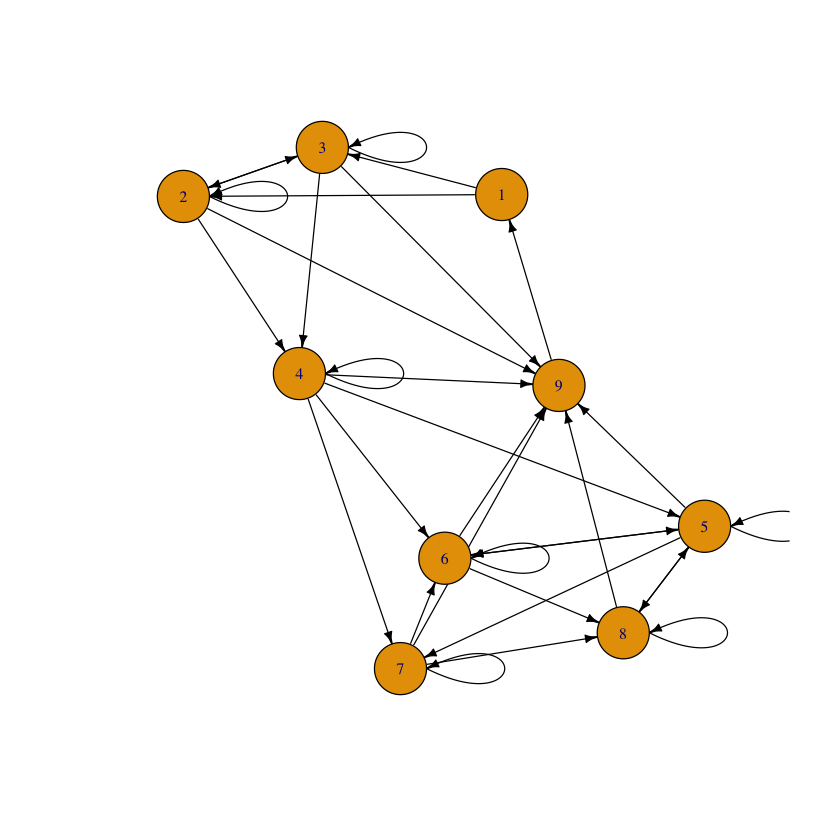

```r
# Load the data
data <- read.table("webtraffic.txt", header = TRUE)

# Initialize the Traffic matrix
Traffic <- matrix(0, 9, 9)

# Fill in the Traffic matrix using the data
for (i in 1:9) {
  for (j in 1:9) {
    Traffic[i, j] <- sum(data[paste0("t", i, j)])
  }
}

# Set Traffic[9,1] = 1000 as stated
Traffic[9,1] <- 1000

# Normalize each row of the matrix
Traffic_prob <- Traffic / rowSums(Traffic)

# Use igraph to visualize the Markov chain
library(igraph)

g <- graph_from_adjacency_matrix(Traffic_prob, mode="directed", weighted=TRUE, diag=TRUE)
plot(g, vertex.size=20, edge.arrow.size=0.5, edge.color="black", vertex.label.cex=0.8)
```

## 1c)

```r
print(Traffic_prob)
```

```
      [,1]       [,2]       [,3]       [,4]      [,5]       [,6]       [,7]
 [1,]    0 0.44700000 0.55300000 0.00000000 0.0000000 0.00000000 0.00000000
 [2,]    0 0.03610675 0.36106750 0.50392465 0.0000000 0.00000000 0.00000000
 [3,]    0 0.20217918 0.05205811 0.62953995 0.0000000 0.00000000 0.00000000
 [4,]    0 0.00000000 0.00000000 0.04971751 0.1785311 0.35254237 0.27909605
 [5,]    0 0.00000000 0.00000000 0.00000000 0.0432220 0.10216110 0.17681729
 [6,]    0 0.00000000 0.00000000 0.00000000 0.1398747 0.04384134 0.00000000
 [7,]    0 0.00000000 0.00000000 0.00000000 0.0000000 0.27325581 0.02034884
 [8,]    0 0.00000000 0.00000000 0.00000000 0.4119497 0.00000000 0.00000000
 [9,]    1 0.00000000 0.00000000 0.00000000 0.0000000 0.00000000 0.00000000
            [,8]      [,9]
 [1,] 0.00000000 0.0000000
 [2,] 0.00000000 0.0989011
 [3,] 0.00000000 0.1162228
 [4,] 0.00000000 0.1401130
 [5,] 0.24950884 0.4282908
 [6,] 0.61377871 0.2025052
 [7,] 0.53779070 0.1686047
 [8,] 0.04716981 0.5408805
 [9,] 0.00000000 0.0000000
```

```r
library('expm')
P_powered = Traffic_prob %^% 5
print(P_powered)
```

```
           [,1]       [,2]       [,3]       [,4]       [,5]       [,6]
 [1,] 0.1523436 0.06952817 0.08989827 0.08368989 0.13151778 0.05916063
 [2,] 0.2163384 0.08609328 0.11147277 0.09500174 0.10015194 0.05420061
 [3,] 0.2301347 0.09095824 0.11609766 0.09643144 0.08817945 0.05483728
 [4,] 0.1811132 0.15940360 0.20403800 0.14555864 0.05295012 0.04586737
 [5,] 0.1340006 0.11694397 0.15238676 0.20805458 0.06741960 0.09557848
 [6,] 0.1094973 0.13601084 0.18161801 0.27287039 0.05175543 0.04919182
 [7,] 0.1196510 0.15267626 0.20050936 0.23634826 0.05126543 0.04451922
 [8,] 0.1298109 0.09095122 0.12048243 0.23084605 0.07322424 0.11613053
 [9,] 0.1150971 0.06138744 0.07846136 0.06759566 0.07067500 0.13803940
            [,7]       [,8]      [,9]
 [1,] 0.03300488 0.15688899 0.2239678
 [2,] 0.04546260 0.09772256 0.1935561
 [3,] 0.04875581 0.09149104 0.1831144
 [4,] 0.03555889 0.05445919 0.1210510
 [5,] 0.07574932 0.03004815 0.1198185
 [6,] 0.04067761 0.03185183 0.1265267
 [7,] 0.03500008 0.03845784 0.1215725
 [8,] 0.09353580 0.02144040 0.1235785
 [9,] 0.08072374 0.23567664 0.1523436
```

## 1d)

What is the probability of a visitor being on Page 5 after 5 clicks?

```r
#install.packages('expm')
library('expm')
```

```r
state_after_n_steps <- function(trans_prob, start_state, target_state, num_steps) {
    trans_prob_powered = trans_prob %^% num_steps  # Raising P to the power of "clicks"
    return(trans_prob_powered[start_state, target_state])
}

result_1d = state_after_n_steps(Traffic_prob, 1, 5, 5)
print(result_1d)
```

```
[1] 0.1315178
```

## 1e)

Compute and display the steady-state probability vector Pi, solving the system of equations (as demonstrated in lab)

```r
steady_state <- function(P) {
  n <- nrow(P)
  # Construct the system of equations
  Q <- t(P - diag(n))

  # Add the constraint that probabilities sum to 1
  Q <- rbind(Q, rep(1,n))

  b <- rep(0, n)
  b[n + 1] <- 1

  # Solve the system of equations
  pi <- qr.solve(Q,b)
  return(pi)
}


steady_state(Traffic_prob)
```

1. 0.158328055731476

2. 0.10085497150095

3. 0.130778974034199

4. 0.140120329322356

5. 0.080588980367321

6. 0.0758391386953768

7. 0.0544648511716276

8. 0.100696643445218

9. 0.158328055731476

## 1f)

The following table represents the average time (in minutes) that a visitor spends on each page:

```
                    Page 1  2 3 4 5 6 7 8
                    Min 0.1 2 3 5 5 3 3 2
```

What is the average time a visitor spends on the website (until he/she first leaves)? Hint: Modify the mean first passage time equations, with time spent at each state.

```r
mean_first_passage_time <- function(P, time_matrix){
    n <- nrow(P)

    # Modify the transition matrix to make it an n-1xn-1 matrix
    # (if the transition to the terminal state is not already excluded)
    P_modified = P[1:n-1, 1:n-1]

    # Identity matrix of size n-1 x n-1
    I = diag(n-1)
    A = I - P_modified
    b = time_matrix[1:n-1]

    t = solve(A, b)
    average_time = t[1]
    return(average_time)
}


time_spent <- c(0.1, 2, 3, 5, 5, 3, 3, 2)
print(mean_first_passage_time(Traffic_prob,time_spent))
```

```
[1] 14.563
```

# Question 2

### Problem 2a

Determine the number of samples required to achieve an error tolerance of 1e-3 with 99% confidence.

**Number of samples needed to ( n ) to meet tolerance with ( (1 - \delta) ) confidence:**
$$ n \geq \frac{\text{var}[p(x)]}{\text{tolerance}^2 \cdot \delta} $$

Given the values:

- $\text{var}[p(x)] = \frac{1}{{\lambda}^2}$
- $\text{tolerance} = 10^{-3}$
- $\delta = 0.01$

Substituting into the formula and simplifying, we get: $$ n \geq 10^{8} \times \frac{1}{{\lambda}^2} $$

### Problem 2b

Compute the approximation (using the number of samples obtained in Problem 2a) and verify that it is within tolerance by comparing to the exact solution: $$ \int_0^{\infty} e^{-\lambda x} \sin x \, dx = \frac{1}{1+\lambda^2} $$ Numerically evaluate for each of $\lambda = 1, 2, 4$.

```r
set.seed(6)
lambdas <- c(1, 2, 4)
mc_estimates <- c()
results_real <- c()

for (i in lambdas) {

  n <- 10^8 / i^2
  x <- runif(n, 0, 1)
  y <- -log(x) / i
  g <- sin(y) / i

  mc_estimates <- append(mc_estimates, mean(g))
  results_real <- append(results_real, 1 / (1 + i^2))

}

tolerance <- 1e-3

for (i in 1:length(lambdas)) {
  cat(paste("Lambda =", lambdas[i]), "\n")
  diff <- abs(mc_estimates[i] - results_real[i])
  if (diff < tolerance) {
    cat(paste("Abs Diff =", diff, ". Therefore it is within tolerance range of", tolerance), "\n")
  } else {
    cat(paste("Abs Diff =", diff, ". Therefore it is not within tolerance range of", tolerance), "\n")
  }
  cat("\n")
}
```

```
Lambda = 1
Abs Diff = 1.2269068055959e-05 . Therefore it is within tolerance range of 0.001

Lambda = 2
Abs Diff = 8.69732678829283e-06 . Therefore it is within tolerance range of 0.001

Lambda = 4
Abs Diff = 1.5205245409558e-05 . Therefore it is within tolerance range of 0.001
```

# Problem 3

### Problem 3a

Which MCMC algorithm (Metropolis, Metropolis-Hastings, or Gibbs) is better suited for this problem?

**Ans** The Metropolis-Hastings algorithm is preferred because of its flexibility in proposal distribution selection, like the exponential in this scenario. Gibbs sampling might not be straightforward due to conditional distributions complexity. The standard Metropolis algorithm would require a symmetric proposal, which doesn't align with the given exponential proposal.

### Problem 3b

Using a burn-in period of 5000 samples and keeping every 100 samples, generate 100 samples from the gamma distribution with shape k = 2 and scale θ = 2. Use the algorithm you chose in Problem 3a and write your own sampler (as opposed to using a function from a package).

```r
gamma_pdf = function (x,k,theta){
  return((x^(k - 1) / (gamma(k) * theta^k)) * exp(-x / theta))
}

metropolis_hastings_simple <- function(n_samples, burn_in, thin, lambda_init, k, theta) {
  # Initialize

  samples <- numeric(burn_in + n_samples * thin)

  # Initialising the initail sample with rate lambda init is a design choice here
  samples[1] <- rexp(1, rate = lambda_init)

  for (i in 2:(burn_in + n_samples * thin)) {
    # For each iteration, we propose a new sample from an exponential distribution with a rate equal
    # to the last accepted sample. This ensures the chain can explore different regions of the target distribution.
    proposed_sample <- rexp(1, rate = samples[i-1])

    # Compute the acceptance ratio
    alpha = gamma_pdf(proposed_sample,k,theta) / gamma_pdf(samples[i-1],k,theta)

    # If a uniformly drawn random number is less than alpha, we accept it; otherwise, we keep the current sample.
    if (runif(1) < min(1,alpha)) {
      samples[i] <- proposed_sample
    } else {
      samples[i] <- samples[i-1]
    }
  }

  # After generating all the samples, we discard the first burn_in samples.
  # Then, we apply thinning to reduce autocorrelation by only keeping every nth sample,
  # where n is specified by thin.
  return(samples[(burn_in + 1):length(samples)][seq(1, n_samples * thin, by = thin)])
}

# Generate samples
samples <- metropolis_hastings_simple(n_samples = 100, burn_in = 5000, thin = 100, lambda_init = 1, k=2, theta=2)

# Inspect the first few samples
head(samples)
```

1. 0.713351112887422

2. 3.18485779515595

3. 3.21098974869096

4. 2.28473222613187

5. 0.633429960155396

6. 4.1163721497519

### Problem 3c

Are the samples generated in Problem 3b sufficiently random? How can you tell?

**Ans** From the scatter plots and timeseries plots plotted below, we can conclude that the sampled points are sufficiently random.

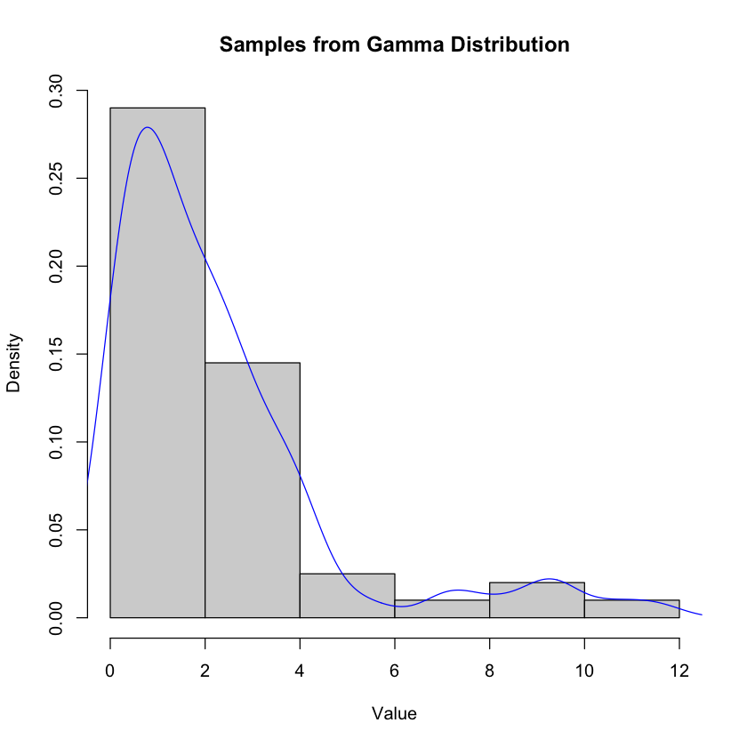

```r
hist(samples, main="Samples from Gamma Distribution", xlab="Value", freq=FALSE)
lines(density(samples), col="blue")
```

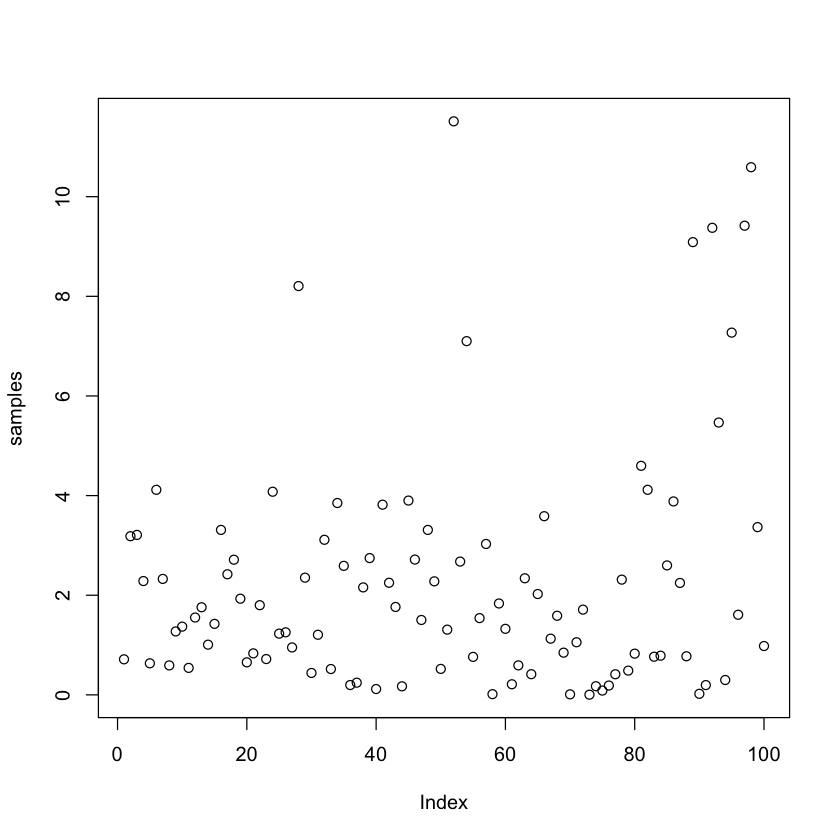

```r
plot(samples)
```

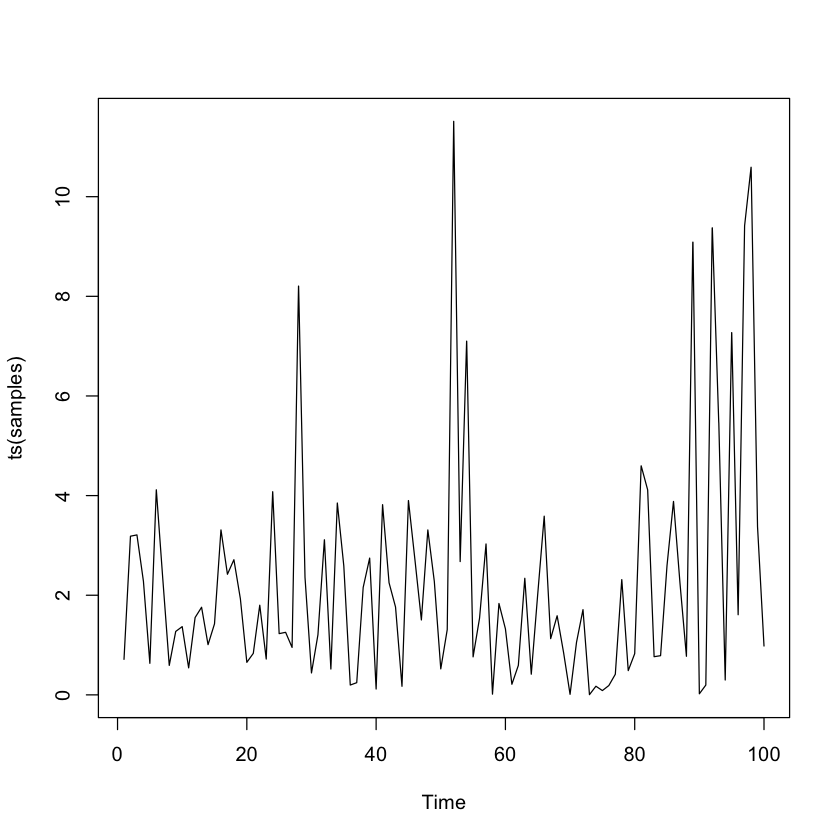

```r
plot(ts(samples))
```